# 3-Arbol-Santiago_Cluster2

Conclusiones K-Modes / Ajuste Árbol Clasificación - CH

25 noviembre, 2022

## Conclusiones ajuste K-Modes / Árbol de decisión:

- De igual forma como utilizando un Árbol de Clasificación determinamos si un postulante a un área del conocimiento y región determinada tendrá como primera preferencia una universidad privada o CRUCH, podemos pronosticar, por ejemplo, si un alumno postulará a alguna universidad de la ciudad de Santiago considerando el área de conocimiento de su interés, región donde le gustaría estudiar y si su opción es una universidad CRUCH o particular.

```r
require(dplyr)
library(cluster)
library(factoextra)
library(tidyverse)
require(caret)
require(klaR)
require(tidymodels)
require(Metrics)
require(rpart.plot)
require(rattle)
require(rpart)
require(baguette)
require(rpart.plot)
library(gridExtra)
library(e1071)
```

### Preparación de la data:

Separamos el clúster 2:

```r
union_preferencia_1 <- read.csv('union_preferencia_1.csv')
pref1 <- union_preferencia_1
apply(is.na(pref1),2,sum)
```

```
##                      X                 id_rut  cod_pond_utilizada_01
##                      0                     86                      0
##           anio_proceso    cod_carrera_pref_01            region_sede
##                      0                      0                   2626
##            nombre_sede      ptje_ponderado_01            comuna_sede
##                   2626                 304311                   2626
##         nombre_carrera cod_est_postulacion_01      postulaciones_bea
##                   2626                      0                      0
##  area_del_conocimiento     tipo_institucion_2             nombre_ies
##                   2626                   2626                   2626
```

```r
pref1 <- pref1 %>%
  dplyr::select(-id_rut, -cod_pond_utilizada_01, -cod_carrera_pref_01, -nombre_sede,
         -cod_est_postulacion_01, -postulaciones_bea, -nombre_carrera, -nombre_ies,
         -ptje_ponderado_01, -X) %>%
  mutate(anio_proceso = factor(anio_proceso),
         region_sede = factor(region_sede),
         area_del_conocimiento = factor(area_del_conocimiento),
         tipo_institucion_2 = factor(tipo_institucion_2),
         comuna_sede = factor(comuna_sede))
pref1 <- as.data.frame(pref1)

apply(is.na(pref1),2,sum)
```

```
##          anio_proceso           region_sede           comuna_sede
##                     0                  2626                  2626
## area_del_conocimiento    tipo_institucion_2
##                  2626                  2626
```

```r
pref1 <- na.omit(pref1)

grupos <- read.csv('pref1.csv')
pref1$cluster <- grupos$cluster
```

```r
A1 <- subset(pref1, cluster == "2")
```

Transformamos a variables dummy y eliminamos variables innecesarias:

```r
library(fastDummies)
A1 <- dummy_cols(A1, select_columns = c('area_del_conocimiento', 'comuna_sede', 'region_sede', 'tipo_institucion_2'))
A1 <- A1 %>%
  dplyr::select(-anio_proceso, -region_sede, -comuna_sede, -area_del_conocimiento, -tipo_institucion_2, -cluster,
         -comuna_sede_ANTOFAGASTA, -comuna_sede_ARICA,
         -comuna_sede_CASTRO, -comuna_sede_CHILLAN, -comuna_sede_CONCEPCION, -comuna_sede_COPIAPO,
         -comuna_sede_COQUIMBO, -comuna_sede_COYHAIQUE, -`comuna_sede_ESTACION CENTRAL`, -comuna_sede_HUALPEN,
         -comuna_sede_HUECHURABA, -comuna_sede_IQUIQUE, -`comuna_sede_LA FLORIDA`, -`comuna_sede_LA SERENA`,
         -`comuna_sede_LAS CONDES`, -comuna_sede_LINARES, -`comuna_sede_LOS ANGELES`, -comuna_sede_MACUL,
         -comuna_sede_MAIPU, -comuna_sede_ÑUÑOA, -comuna_sede_OSORNO, -comuna_sede_OVALLE, -comuna_sede_PEÑALOLEN,
         -comuna_sede_PROVIDENCIA, -`comuna_sede_PUERTO MONTT`, -`comuna_sede_PUNTA ARENAS`, -comuna_sede_RANCAGUA,
         -`comuna_sede_SAN FELIPE`, -`comuna_sede_SAN FERNANDO`, -`comuna_sede_SAN JOAQUIN`,
         -`comuna_sede_SAN MIGUEL`, -`comuna_sede_SANTA CRUZ`,
         -comuna_sede_TALCAHUANO, -comuna_sede_TEMUCO, -comuna_sede_VALDIVIA, -comuna_sede_VALLENAR,
         -comuna_sede_VICTORIA, -comuna_sede_VILLARRICA, -comuna_sede_VALPARAISO,
         -comuna_sede_VITACURA, -comuna_sede_TALCA, -comuna_sede_CURICO, -`comuna_sede_VIÑA DEL MAR`,
         -`tipo_institucion_2_Universidades Privadas`) %>%
  mutate(comuna_sede_SANTIAGO = factor(comuna_sede_SANTIAGO))
glimpse(A1)
```

```
## Rows: 254,879
## Columns: 28
## $ `area_del_conocimiento_Administración y Comercio`                 <int> 0, 0…
## $ area_del_conocimiento_Agropecuaria                                <int> 0, 0…
## $ `area_del_conocimiento_Arte y Arquitectura`                       <int> 0, 0…
## $ `area_del_conocimiento_Ciencias Básicas`                          <int> 0, 0…
## $ `area_del_conocimiento_Ciencias Sociales`                         <int> 1, 1…
## $ area_del_conocimiento_Derecho                                     <int> 0, 0…
## $ area_del_conocimiento_Educación                                   <int> 0, 0…
## $ area_del_conocimiento_Humanidades                                 <int> 0, 0…
## $ area_del_conocimiento_Salud                                       <int> 0, 0…
## $ area_del_conocimiento_Tecnología                                  <int> 0, 0…
## $ comuna_sede_SANTIAGO                                              <fct> 0, 1…
## $ `region_sede_REGION DE ANTOFAGASTA`                               <int> 0, 0…
## $ `region_sede_REGION DE ARICA Y PARINACOTA`                        <int> 0, 0…
## $ `region_sede_REGION DE ATACAMA`                                   <int> 0, 0…
## $ `region_sede_REGION DE AYSEN DEL GENERAL CARLOS IBAÑEZ DEL CAMPO` <int> 0, 0…
## $ `region_sede_REGION DE COQUIMBO`                                  <int> 0, 0…
## $ `region_sede_REGION DE LA ARAUCANIA`                              <int> 0, 0…
## $ `region_sede_REGION DE LOS LAGOS`                                 <int> 0, 0…
## $ `region_sede_REGION DE LOS RIOS`                                  <int> 0, 0…
## $ `region_sede_REGION DE MAGALLANES Y DE LA ANTARTICA CHILENA`      <int> 0, 0…
## $ `region_sede_REGION DE ÑUBLE`                                     <int> 0, 0…
## $ `region_sede_REGION DE TARAPACA`                                  <int> 0, 0…
## $ `region_sede_REGION DE VALPARAISO`                                <int> 0, 0…
## $ `region_sede_REGION DEL BIOBIO`                                   <int> 0, 0…
## $ `region_sede_REGION DEL LIBERTADOR BERNARDO OHIGGINS`             <int> 0, 0…
## $ `region_sede_REGION DEL MAULE`                                    <int> 1, 0…
## $ `region_sede_REGION METROPOLITANA`                                <int> 0, 1…
## $ `tipo_institucion_2_Universidades CRUCH`                          <int> 0, 1…
```

Obtenemos set de entrenamiento y testeo:

```r
set.seed(20220901)
traintest_split <- initial_split(A1, prop = 0.7, strata = NULL)
train_set <- training(traintest_split)
test_set <- testing(traintest_split)
dim(train_set)
```

```
## [1] 178415     28
```

Tuneamos:

```r
tuned_model2 <- decision_tree(cost_complexity = tune(), tree_depth = tune()) %>%
    set_engine('rpart') %>%
    set_mode('classification')
```

```r
tree_grid2 <- grid_regular(cost_complexity(),
                          tree_depth(),
                          levels = 5)
```

Validación cruzada:

```r
set.seed(20220901)
set_folds <- vfold_cv(train_set)
```

Receta:

```r
receta2 <- recipe(comuna_sede_SANTIAGO ~ .,data = train_set)
```

Flujo:

```r
tree_workflow2 <- workflow() %>%
    add_model(tuned_model2) %>%
    add_recipe(receta2)
```

Arbol tuneado:

```r
tree_tuning2 <- tree_workflow2 %>%
    tune_grid(resamples = set_folds, grid = tree_grid2)
```

```r
tree_tuning2
```

```
## # Tuning results
## # 10-fold cross-validation
## # A tibble: 10 × 4
##    splits                 id     .metrics          .notes
##    <list>                 <chr>  <list>            <list>
##  1 <split [160573/17842]> Fold01 <tibble [50 × 6]> <tibble [0 × 3]>
##  2 <split [160573/17842]> Fold02 <tibble [50 × 6]> <tibble [0 × 3]>
##  3 <split [160573/17842]> Fold03 <tibble [50 × 6]> <tibble [0 × 3]>
##  4 <split [160573/17842]> Fold04 <tibble [50 × 6]> <tibble [0 × 3]>
##  5 <split [160573/17842]> Fold05 <tibble [50 × 6]> <tibble [0 × 3]>
##  6 <split [160574/17841]> Fold06 <tibble [50 × 6]> <tibble [0 × 3]>
##  7 <split [160574/17841]> Fold07 <tibble [50 × 6]> <tibble [0 × 3]>
##  8 <split [160574/17841]> Fold08 <tibble [50 × 6]> <tibble [0 × 3]>
##  9 <split [160574/17841]> Fold09 <tibble [50 × 6]> <tibble [0 × 3]>
## 10 <split [160574/17841]> Fold10 <tibble [50 × 6]> <tibble [0 × 3]>
```

```r
tree_tuning2 %>%
  show_best('roc_auc')
```

```
## # A tibble: 5 × 8
##   cost_complexity tree_depth .metric .estimator  mean     n  std_err .config
##             <dbl>      <int> <chr>   <chr>      <dbl> <int>    <dbl> <chr>
## 1    0.000562             11 roc_auc binary     0.832    10 0.000875 Preprocess…
## 2    0.000562             15 roc_auc binary     0.832    10 0.000875 Preprocess…
## 3    0.0000000001         11 roc_auc binary     0.832    10 0.000872 Preprocess…
## 4    0.0000000178         11 roc_auc binary     0.832    10 0.000872 Preprocess…
## 5    0.00000316           11 roc_auc binary     0.832    10 0.000872 Preprocess…
```

```r
best_tree2 <- tree_tuning2 %>%
  select_best('roc_auc')
best_tree2
```

```
## # A tibble: 1 × 3
##   cost_complexity tree_depth .config
##             <dbl>      <int> <chr>
## 1        0.000562         11 Preprocessor1_Model19
```

```r
tree_workflow_final2 <- tree_workflow2 %>%
  finalize_workflow(best_tree2)
```

```r
tree_fit_tune2 <- tree_workflow_final2 %>%
  last_fit(traintest_split)
tree_fit_tune2
```

```
## # Resampling results
## # Manual resampling
## # A tibble: 1 × 6
##   splits                 id               .metrics .notes   .predic…¹ .workflow
##   <list>                 <chr>            <list>   <list>   <list>    <list>
## 1 <split [178415/76464]> train/test split <tibble> <tibble> <tibble>  <workflow>
## # … with abbreviated variable name ¹.predictions
```

```r
tree_fit_tune2 %>%
  collect_metrics() # roc_auc = 0.8346148   accuracy = 0.7510201
```

```
## # A tibble: 2 × 4
##   .metric  .estimator .estimate .config
##   <chr>    <chr>          <dbl> <chr>
## 1 accuracy binary         0.751 Preprocessor1_Model1
## 2 roc_auc  binary         0.835 Preprocessor1_Model1
```

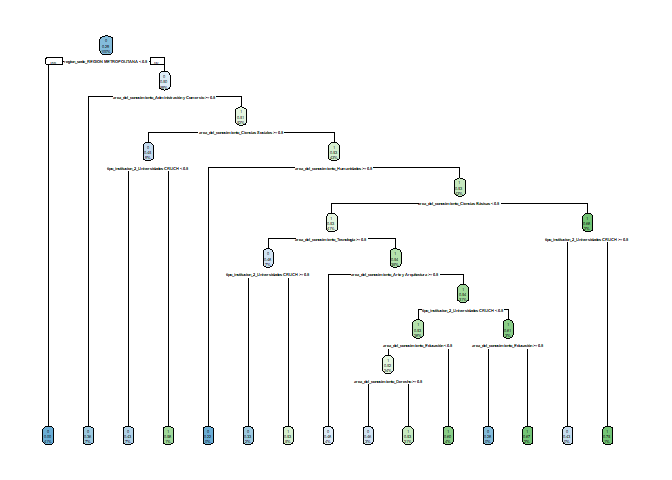

```r
tree_fit_tune2 %>%
    extract_fit_engine() %>%
    rpart.plot(roundint = FALSE)
```

Considerando el roc_auc como criterio podemos asumir que el ajuste realizado es bastante aceptable, ya que su valor es 0,8346148. Lo anterior nos permite aceptar este modelo como una herramienta que podría ser utilizada, por ejemplo, para estimar el mercado potencial de estudiantes universitarios de primer año en alguna ciudad, dadas algunas de sus preferencia, como en este caso la región donde le gustaría estudiar, el área del concimiento de su carrera y si optaría por una universidad privada o CRUCH. Todo lo anterior enmarcado en el contexto de la pandemia, o alguna situación que determine condiciones similares (restricción a la movilidad, conflictos sociales, insertidumbre generalizada, etc.)